# Taipei Metro Analysis / team8

## 問題意識

我們從台北市政府開放資料平台上抓取[臺北捷運各站進出量統計](http://data.taipei/opendata/datalist/datasetMeta?oid=1d71c478-205f-42c5-8386-35f86d74fdd1)，裡面的資料有歷年台北捷運每站每日的進出量數字。我們好奇一星期中，週間工作日與週末的捷運進出量人次會不會有差別，以及各捷運站與各線的進出量在一週七天中的分佈模式有哪些異同。

## 一、資料前處理

為了方便分析，我們使用 2015 年 1 月到 2015 年 12 月的台北捷運進出量統計資料，我們先把 12 個月份檔案合為一份，再加入星期資訊、路線資訊，並將表格轉為data.frame、類別變數轉為 factor 方便之後分析。

先匯入所需使用的 packages

```r
  #Sys.setlocale(category = "LC_ALL", locale = "cht")
  Sys.setlocale(category = "LC_ALL", locale = "zh_TW.UTF-8")
  require(dplyr)
  require(tidyr)
  require(ggplot2)
```

## (1)資料整理(把資料整理為可分析格式)

### (1-a)把十二個月個資料整理成一份csv檔，命名為metro

Note：因為在2015年度，一月和十二月之間，捷運站從107站增為108站(多了頂埔站)，為了分析一致，所以只挑選出這十二個月都有的107站。

```r
  metro = data.frame()
  setwd("~/dsR/team8_week7")
  fileindex=c("01","02","03","04","05","06",
              "07","08","09","10","11","12")

   #先找出1月就已經存在的107個站名
   tmp=read.csv("201501.csv", header = T, stringsAsFactors = FALSE, fileEncoding="big5")
   name1=names(tmp)

  #讀取12個月的資料(只讀取那107個站)
    for (i in 1: 12)
      {
    csvfile = paste("2015",fileindex[i],".csv", sep="")
    tmp=read.csv(csvfile, sep = ",", header = T, stringsAsFactors = FALSE, fileEncoding="big5")
    tmp=tmp[,colnames(tmp) %in% name1]
    metro = bind_rows(metro, tmp)
    }
```

### 顯示資料原始格式(合併完，待轉換成可分析格式)

```r
tbl_df(metro)[1:5,1:10]
```

```
## # A tibble: 5 × 10
##       日期 松山機場 中山國中 南京復興 忠孝復興   大安 科技大樓 六張犁
##      <chr>    <chr>    <chr>    <chr>    <chr>  <chr>    <chr>  <chr>
## 1 2015/1/1    4,417   10,131   17,318   51,438 11,067    8,230  7,997
## 2 2015/1/2    4,360   10,136   18,182   54,697 11,889    8,876  7,965
## 3 2015/1/3    4,886   10,559   17,895   50,681 12,116    8,656  8,002
## 4 2015/1/4    5,684    8,915   14,999   41,296 10,578    8,077  6,989
## 5 2015/1/5    5,505   16,100   30,256   42,400 22,609   15,189 11,471
## # ... with 2 more variables: 麟光 <chr>, 辛亥 <chr>
```

### (1-b) 把資料metro轉成long format，才能加以分析(透過tidyr::gather)

即把站名轉成factor、進出人次轉成為一個觀察變項。

```r
metro=
   metro %>%
   gather("站名","人次", -日期)
```

### (1-c)把變項補齊(運用pipleline和tidyr)

把「星期」、「週末/週間」變項加上去。 並把「日期(年/月/日)」拆解出「年」、「月」、「日」的變項。(運用tidyr::seperate)

```r
#把日期拆分，變成「年」、「月」、「日」等變項
metro=metro%>%
  separate(日期,c("年","月","日"))

#創造「星期」的變項
#2015/01/01是星期四，所以從星期四開始編
day=rep(c("星期四","星期五","星期六","星期日","星期一","星期二","星期三"),times=52)
day=c(day,"星期四")#因為2015/12/31是星期四
metro$星期= factor(day)

#創造「週末/週間」變項
metro$週末週間=ifelse(metro$星期 %in% c("星期六","星期日"),"週末","週間")

#把變項的類別修正
metro[,c(1,2,3)]=
  metro%>%
  select(年,月,日)%>%
  mutate_each(funs(as.numeric(.)))

metro[,c(4,7)]=
  metro%>%
  select(站名,週末週間)%>%
  mutate_each(funs(as.factor(.)))

metro$人次=as.numeric(gsub(",", "",metro$人次))#把數字中的逗號移去

tbl_df(metro)
```

```
## # A tibble: 39,055 × 7
##       年    月    日     站名  人次   星期 週末週間
## *  <dbl> <dbl> <dbl>   <fctr> <dbl> <fctr>   <fctr>
## 1   2015     1     1 松山機場  4417 星期四     週間
## 2   2015     1     2 松山機場  4360 星期五     週間
## 3   2015     1     3 松山機場  4886 星期六     週末
## 4   2015     1     4 松山機場  5684 星期日     週末
## 5   2015     1     5 松山機場  5505 星期一     週間
## 6   2015     1     6 松山機場  5131 星期二     週間
## 7   2015     1     7 松山機場  4905 星期三     週間
## 8   2015     1     8 松山機場  5061 星期四     週間
## 9   2015     1     9 松山機場  5684 星期五     週間
## 10  2015     1    10 松山機場  4306 星期六     週末
## # ... with 39,045 more rows
```

```r
#write.csv(metro,"Metro.csv")
```

### (1-d)把各站所屬「路線」(如:淡水信義線)加上

#### 因為非常簡單，所以路線的資訊直接用excel添加，存成csv檔。

#### 讀取編輯好的檔案

```r
metro <- read.csv("Metro2.csv",sep = ",", header = T, fileEncoding="big5")
tbl_df(metro)
```

```
## # A tibble: 39,055 × 14
##        X    年    月    日     站名  人次   星期 週末週間 文湖線
##    <int> <int> <int> <int>   <fctr> <int> <fctr>   <fctr>  <lgl>
## 1      1  2015     1     1 松山機場  4417 星期四     週間   TRUE
## 2      2  2015     1     2 松山機場  4360 星期五     週間   TRUE
## 3      3  2015     1     3 松山機場  4886 星期六     週末   TRUE
## 4      4  2015     1     4 松山機場  5684 星期日     週末   TRUE
## 5      5  2015     1     5 松山機場  5505 星期一     週間   TRUE
## 6      6  2015     1     6 松山機場  5131 星期二     週間   TRUE
## 7      7  2015     1     7 松山機場  4905 星期三     週間   TRUE
## 8      8  2015     1     8 松山機場  5061 星期四     週間   TRUE
## 9      9  2015     1     9 松山機場  5684 星期五     週間   TRUE
## 10    10  2015     1    10 松山機場  4306 星期六     週末   TRUE
## # ... with 39,045 more rows, and 5 more variables: 淡水信義線 <lgl>,
## #   松山新店線 <lgl>, 中和新蘆線 <lgl>, 板南線 <lgl>, 轉運站 <lgl>
```

## 一、星期的總效應

將資料前處理後，用dplyr的select function選出「人次」跟「星期」

```r
weekeffect <- metro %>%
  select(人次, 星期)
```

算出各個星期的平均人數

```r
mon <- filter(weekeffect, 星期=="星期一")
tue <- filter(weekeffect, 星期=="星期二")
wed <- filter(weekeffect, 星期=="星期三")
thu <- filter(weekeffect, 星期=="星期四")
fri <- filter(weekeffect, 星期=="星期五")
sat <- filter(weekeffect, 星期=="星期六")
sun <- filter(weekeffect, 星期=="星期日")

monsum <- mean(mon$人次)
tuesum <- mean(tue$人次)
wedsum <- mean(wed$人次)
thusum <- mean(thu$人次)
frisum <- mean(fri$人次)
satsum <- mean(sat$人次)
sunsum <- mean(sun$人次)

weekday <- factor(c("Mon", "Tue", "Wed", "Thu", "Fri", "Sat", "Sun"), levels = c("Mon", "Tue", "Wed", "Thu", "Fri", "Sat", "Sun"))

peoplemean <- c(monsum, tuesum, wedsum, thusum, frisum, satsum, sunsum)

weekeffectmean <- data.frame(weekday, peoplemean)

weekeffectmean
```

```
##   weekday peoplemean
## 1     Mon   18131.01
## 2     Tue   18676.13
## 3     Wed   18900.61
## 4     Thu   19288.50
## 5     Fri   19877.43
## 6     Sat   17913.99
## 7     Sun   15433.60
```

用ggplot看圖形，發現星期六日的平均人次比週間少

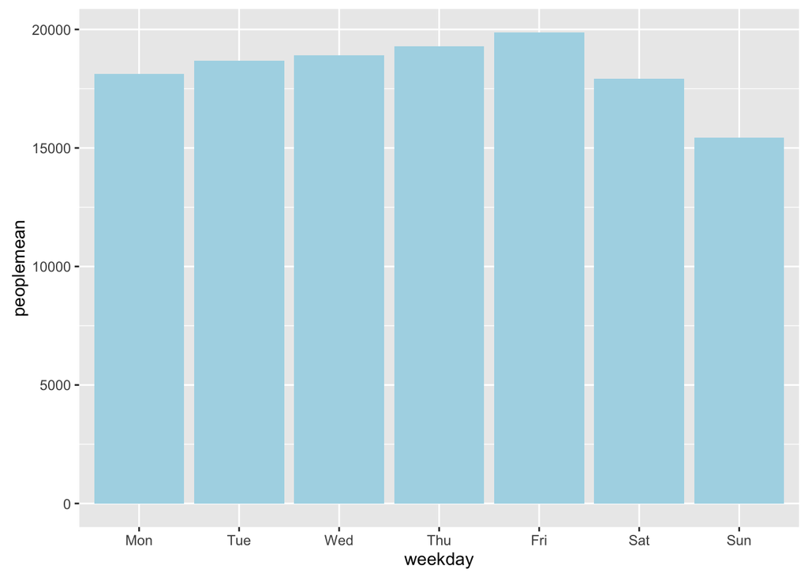

```r
ggplot(weekeffectmean, aes(weekday, peoplemean)) +
  geom_bar(stat = "identity", fill = I('lightblue'))
```

## 二、各站的星期效應

初步分析得到六日的平均人次比週間少，那如果各站分別來看，分佈會跟平均人數所顯示出來的趨勢不同嗎？

#### 按各站週間週末全年平均的差距，將全部107站分為四組(四分位數依序為801.6,1827,4479)

```r
station<-metro%>%group_by(週末週間,站名)%>%summarize(avg=mean(人次))

weekday<-filter(station,週末週間=="週間")
weekday<-rename(weekday,weekavg=avg)


weekend<-filter(station,週末週間=="週末")
weekend<-rename(weekend,weekendavg=avg)
all<-merge.data.frame(weekday,weekend,by="站名",all=TRUE)
all<-all%>%select(站名,weekavg,weekendavg) %>%mutate(gap=weekavg-weekendavg)
summary(all$gap)
```

```
##     Min.  1st Qu.   Median     Mean  3rd Qu.     Max.
## -27160.0    801.6   1827.0   2302.0   4479.0  17230.0
```

```r
negative<-filter(all,gap<0)
first<-filter(all,gap<=801.6&gap>0)
second<-filter(all,gap<=1827&gap>=801.6)
third<-filter(all,gap>=1827&gap<=4479)
fourth<-filter(all,gap>=4479)
negative<-reshape(negative,direction="long",idvar="站名",varying=list(c("weekendavg","weekavg")),v.names="平均人次")
negative<-rename(negative,week=time)
negative$week=ifelse(negative$week==1,"週末","週間")
first<-reshape(first,direction="long",idvar="站名",varying=list(c("weekendavg","weekavg")),v.names="平均人次")
first<-rename(first,week=time)
first$week=ifelse(first$week==1,"週末","週間")
second<-reshape(second,direction="long",idvar="站名",varying=list(c("weekendavg","weekavg")),v.names="平均人次")
second<-rename(second,week=time)
second$week=ifelse(second$week==1,"週末","週間")
third<-reshape(third,direction="long",idvar="站名",varying=list(c("weekendavg","weekavg")),v.names="平均人次")
third<-rename(third,week=time)
third$week=ifelse(third$week==1,"週末","週間")
fourth<-reshape(fourth,direction="long",idvar="站名",varying=list(c("weekendavg","weekavg")),v.names="平均人次")
fourth<-rename(fourth,week=time)
fourth$week=ifelse(fourth$week==1,"週末","週間")
```

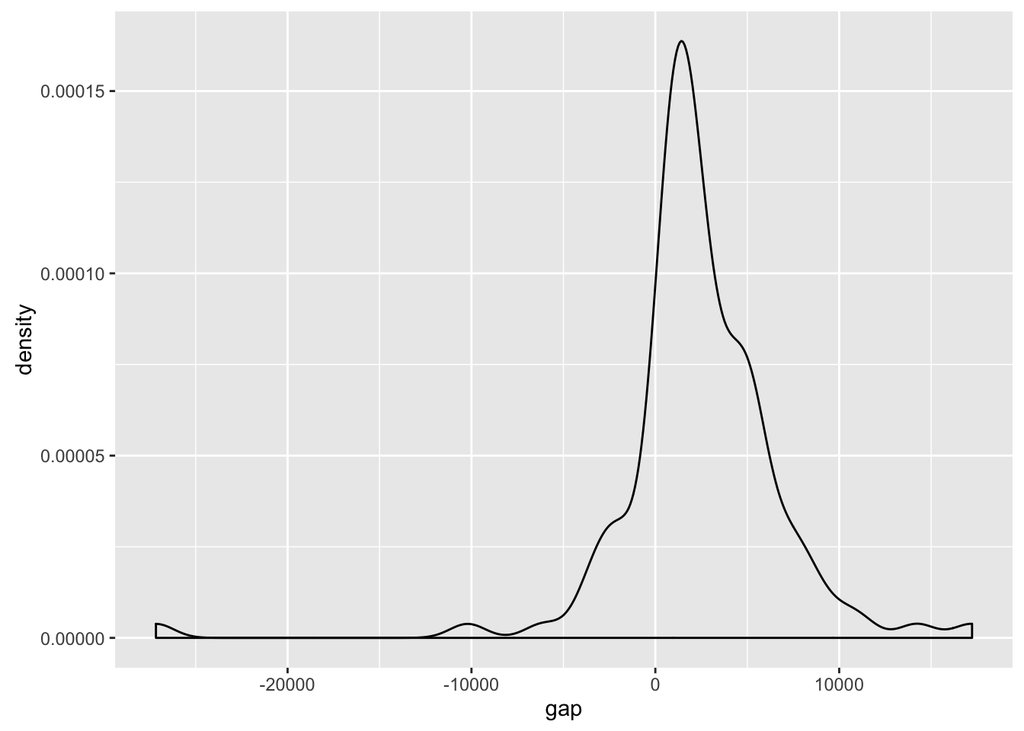

```r
ggplot(all, aes(gap)) +
  geom_density()
```

以下根據週間與週末的進出量差異分為四組： ####weekday週間人數的車站皆為101、公館、美麗華等熱門景點。符合直觀。最大的差距車站為台北車站，一年週間週末平均差距高達27000，但除了北車以外其他地點週間週末差距不大。

```r
negative[negative$week=="週末","站名"]
```

```
##  [1] 板橋         大安森林公園 大湖公園     淡水         動物園
##  [6] 公館         劍南路       劍潭         台北101.世貿 台北車站
## [11] 西門         小碧潭       新北投       圓山         中山
## [16] 忠孝復興
## 107 Levels: 板橋 北門 北投 菜寮 大安 大安森林公園 大湖公園 ... 竹圍
```

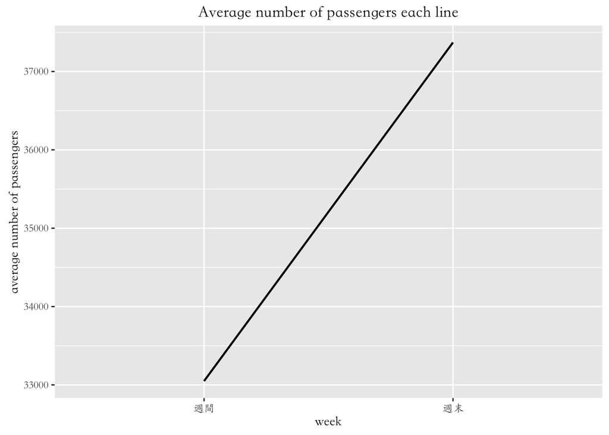

```r
negative<-negative%>%group_by(week)%>%summarize(avg=mean(平均人次))
ggplot(negative, aes(x=week, y=avg,group=1)) +geom_line(size=0.8)+labs(title="Average number of passengers each line", x="week", y="average number of passengers") +theme_grey(base_family = "STKaiti")
```

####weekday>weekend第一組週間週末 此組的車站多為遠離商業區的住宅區。因此週間週末人數並不會差距太大。

```r
first[first$week=="週末","站名"]
```

```
##  [1] 復興崗   麟光     三重     台北橋   台電大樓 頭前庄   土城
##  [8] 萬芳社區 辛亥     新店     新莊
## 107 Levels: 板橋 北門 北投 菜寮 大安 大安森林公園 大湖公園 ... 竹圍
```

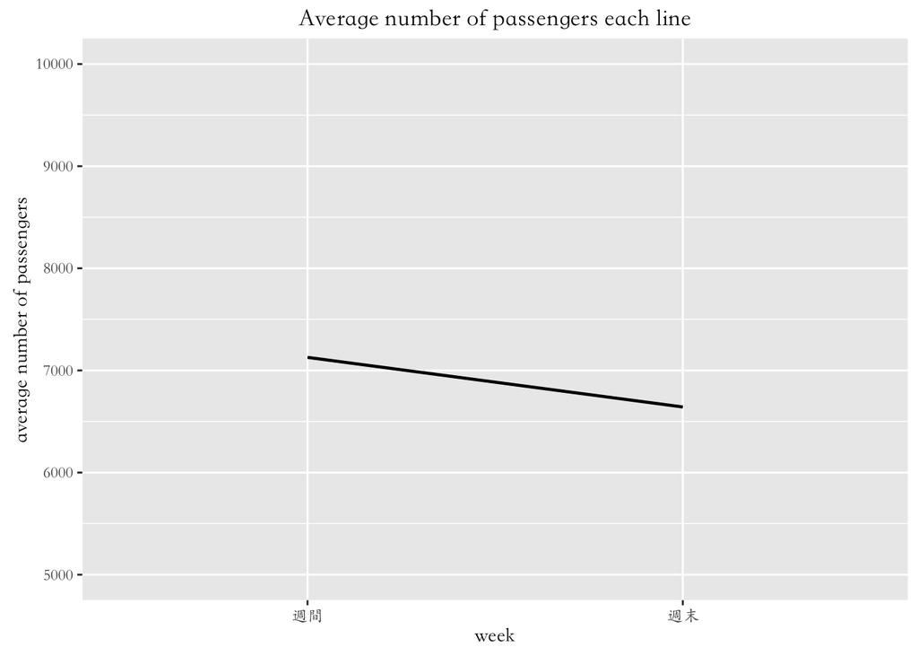

```r
first<-first%>%group_by(week)%>%summarize(avg=mean(平均人次))
ggplot(first, aes(x=week, y=avg,group=1)) +geom_line(size=0.8)+labs(title="Average number of passengers each line", x="week", y="average number of passengers")+ylim(5000,10000)  +theme_grey(base_family = "STKaiti")
```

####weekday>weekend第二組週間週末: 此組的車站多為較接近商業區的住宅區。因此週間週末人數比第一組差距稍大。還有一些學校上榜，效果應來自學生老師。

```r
second[second$week=="週末","站名"]
```

```
##  [1] 北門     菜寮     大橋頭   丹鳳     東湖     東門     府中
##  [8] 紅樹林   迴龍     景美     龍山寺   蘆洲     木柵     內湖
## [15] 三民高中 三重國小 市政府   松山機場 萬隆     文德     徐匯中學
## [22] 永寧     芝山     忠孝新生 忠義     竹圍
## 107 Levels: 板橋 北門 北投 菜寮 大安 大安森林公園 大湖公園 ... 竹圍
```

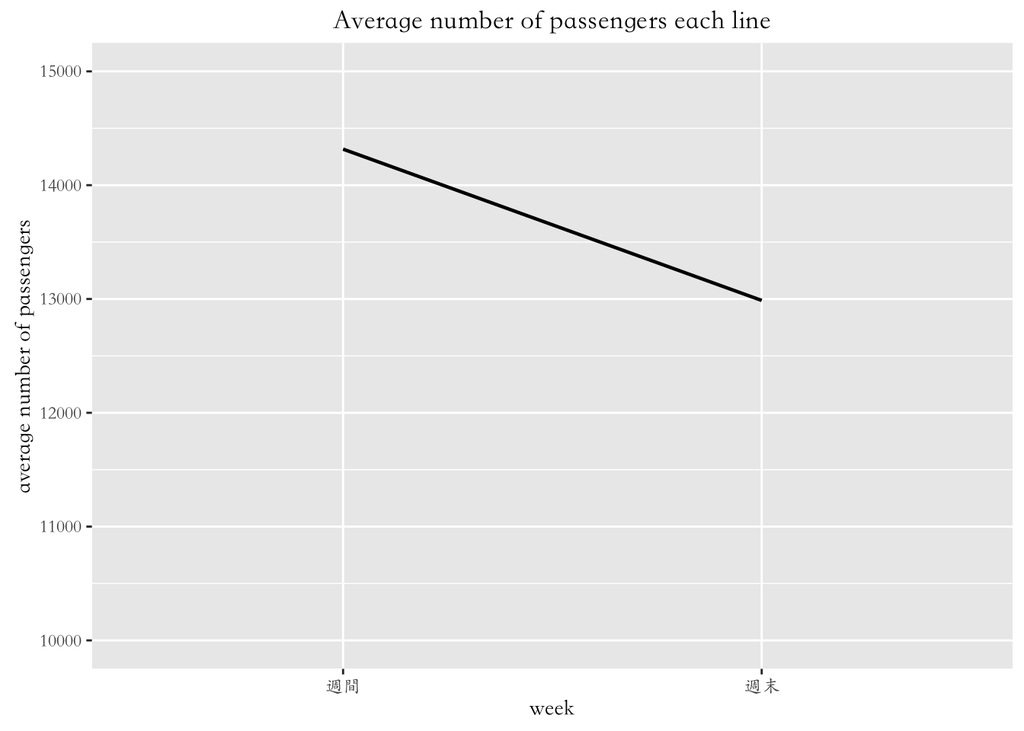

```r
second<-second%>%group_by(week)%>%summarize(avg=mean(平均人次))
ggplot(second, aes(x=week, y=avg,group=1)) +geom_line(size=0.8)+labs(title="Average number of passengers each line", x="week", y="average number of passengers")+ylim(10000,15000)+theme_grey(base_family = "STKaiti")
```

#### weekday>weekend第三組週間週末。

此組上榜的皆為較熱鬧的商業區。週間週末差距拉大

```r
third[third$week=="週末","站名"]
```

```
##  [1] 北投         大直         輔大         關渡         國父紀念館
##  [6] 海山         後山埤       葫洲         六張犁       明德
## [11] 南港         南港軟體園區 南勢角       七張         奇岩
## [16] 唭哩岸       三和國中     士林         松山         先嗇宮
## [21] 象山         小南門       新店區公所   信義安和     永安市場
## [26] 中正紀念堂   忠孝敦化
## 107 Levels: 板橋 北門 北投 菜寮 大安 大安森林公園 大湖公園 ... 竹圍
```

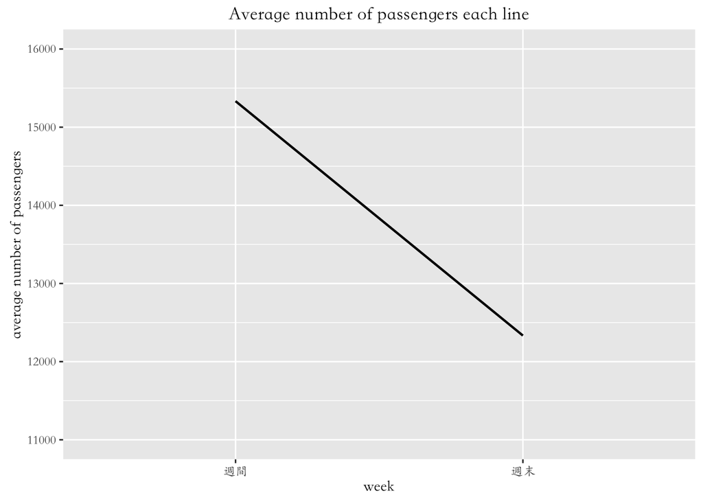

```r
third<-third%>%group_by(week)%>%summarize(avg=mean(平均人次))
ggplot(third, aes(x=week, y=avg,group=1)) +geom_line(size=0.8)+labs(title="Average number of passengers each line", x="week", y="average number of passengers")+ylim(11000,16000)+theme_grey(base_family = "STKaiti")
```

####weekday>weekend第四組週間週末: 醫院皆落在此組。因為除非急診，一般人不會周末跑到醫院。其他上榜的站為南港展覽館等商業區。

```r
fourth[fourth$week=="週末","站名"]
```

```
##  [1] 大安       大坪林     頂溪       港墘       古亭       江子翠
##  [7] 景安       科技大樓   昆陽       民權西路   南港展覽館 南京復興
## [13] 南京三民   善導寺     石牌       雙連       松江南京   台北小巨蛋
## [19] 台大醫院   萬芳醫院   西湖       新埔       行天宮     亞東醫院
## [25] 永春       中山國小   中山國中
## 107 Levels: 板橋 北門 北投 菜寮 大安 大安森林公園 大湖公園 ... 竹圍
```

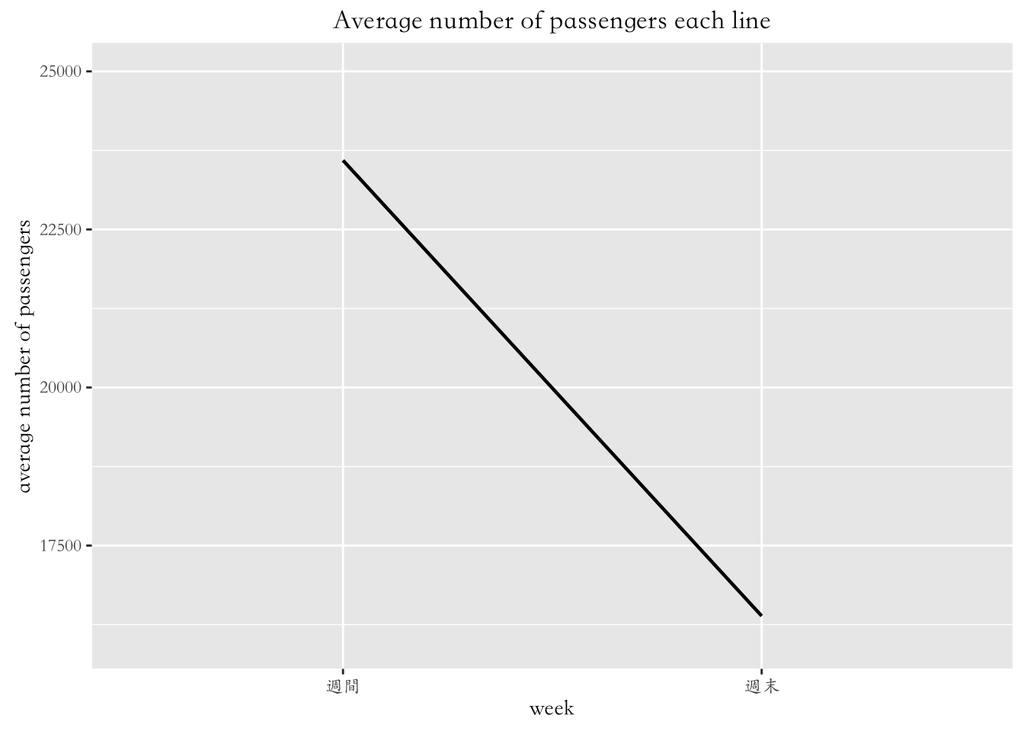

```r
fourth<-fourth%>%group_by(week)%>%summarize(avg=mean(平均人次))
ggplot(fourth, aes(x=week, y=avg,group=1)) +geom_line(size=0.8)+labs(title="Average number of passengers each line", x="week", y="average number of passengers")+ylim(16000,25000)+theme_grey(base_family = "STKaiti")
```

## 三、星期效應與各線的交互作用

以上是各站因為是商業區、醫院、學校、住宅區等造成一星期中週間與週末搭乘量之不同，如果我們是綜合來看一條捷運線呢？

```r
library(dplyr)
library(ggplot2)
str(metro)
```

```
## 'data.frame':    39055 obs. of  14 variables:
##  $ X         : int  1 2 3 4 5 6 7 8 9 10 ...
##  $ 年        : int  2015 2015 2015 2015 2015 2015 2015 2015 2015 2015 ...
##  $ 月        : int  1 1 1 1 1 1 1 1 1 1 ...
##  $ 日        : int  1 2 3 4 5 6 7 8 9 10 ...
##  $ 站名      : Factor w/ 107 levels "板橋","北門",..: 65 65 65 65 65 65 65 65 65 65 ...
##  $ 人次      : int  4417 4360 4886 5684 5505 5131 4905 5061 5684 4306 ...
##  $ 星期      : Factor w/ 7 levels "星期二","星期六",..: 5 6 2 3 7 1 4 5 6 2 ...
##  $ 週末週間  : Factor w/ 2 levels "週間","週末": 1 1 2 2 1 1 1 1 1 2 ...
##  $ 文湖線    : logi  TRUE TRUE TRUE TRUE TRUE TRUE ...
##  $ 淡水信義線: logi  FALSE FALSE FALSE FALSE FALSE FALSE ...
##  $ 松山新店線: logi  FALSE FALSE FALSE FALSE FALSE FALSE ...
##  $ 中和新蘆線: logi  FALSE FALSE FALSE FALSE FALSE FALSE ...
##  $ 板南線    : logi  FALSE FALSE FALSE FALSE FALSE FALSE ...
##  $ 轉運站    : logi  FALSE FALSE FALSE FALSE FALSE FALSE ...
```

> 計算各線週間、週末的平均進站人次

##### 從metro中挑選「人次」這一欄，再用 filter 將捷運各線和週間、週末各自篩選出來後，計算「人次」的平均，即為各線週間、週末的平均進站人次

```r
# 文湖線週間
brownWD <- filter(select(metro, 人次), metro$文湖線 == TRUE & metro$週末週間 == "週間" )
brownWD_avg <- mean(brownWD$人次)

# 文湖線週末
brownWE <- filter(select(metro, 人次), metro$文湖線 == TRUE & metro$週末週間 == "週末" )
brownWE_avg <- mean(brownWE$人次)

# 淡水信義線週間
redWD <- filter(select(metro, 人次), metro$淡水信義線 == TRUE & metro$週末週間 == "週間" )
redWD_avg <- mean(redWD$人次)

# 淡水信義線週末
redWE <- filter(select(metro, 人次), metro$淡水信義線 == TRUE & metro$週末週間 == "週末" )
redWE_avg <- mean(redWE$人次)

# 松山新店線週間
greenWD <- filter(select(metro, 人次), metro$松山新店線 == TRUE & metro$週末週間 == "週間" )
greenWD_avg <- mean(greenWD$人次)

# 松山新店線週末
greenWE <- filter(select(metro, 人次), metro$松山新店線 == TRUE & metro$週末週間 == "週末" )
greennWE_avg <- mean(greenWE$人次)

# 中和新蘆線週間
orangeWD <- filter(select(metro, 人次), metro$中和新蘆線 == TRUE & metro$週末週間 == "週間" )
orangeWD_avg <- mean(orangeWD$人次)

# 中和新蘆線週末
orangeWE <- filter(select(metro, 人次), metro$中和新蘆線 == TRUE & metro$週末週間 == "週末" )
orangeWE_avg <- mean(orangeWE$人次)

# 板南線週間
blueWD <- filter(select(metro, 人次), metro$板南線 == TRUE & metro$週末週間 == "週間" )
blueWD_avg <- mean(blueWD$人次)

# 板南線週末
blueWE <- filter(select(metro, 人次), metro$板南線 == TRUE & metro$週末週間 == "週末" )
blueWE_avg <- mean(blueWE$人次)
```

> 將上面計算出來的捷運各線週間、週末平均進站人數放進一個 dataframe 裡

##### week：週間（weekdays）or 週末（weekends）

```r
df <- data.frame(
  MRT = c("WenHu", "WenHu", "Tamsui-XinYi", "Tamsui-XinYi", "SongSang-XinDian", "SongSang-XinDian", "ZhongHe-XinLu", "ZhongHe-XinLu", "Bannan", "Bannan"),
  avg = c(brownWD_avg, brownWE_avg, redWD_avg, redWE_avg, greenWD_avg, greennWE_avg, orangeWD_avg, orangeWE_avg, blueWD_avg, blueWE_avg),
  week = c("weekdays", "weekends", "weekdays", "weekends", "weekdays", "weekends", "weekdays", "weekends", "weekdays", "weekends")
); df
```

```
##                 MRT       avg     week
## 1             WenHu 12881.587 weekdays
## 2             WenHu  9673.589 weekends
## 3      Tamsui-XinYi 23644.618 weekdays
## 4      Tamsui-XinYi 22575.461 weekends
## 5  SongSang-XinDian 21946.592 weekdays
## 6  SongSang-XinDian 18882.573 weekends
## 7     ZhongHe-XinLu 16742.707 weekdays
## 8     ZhongHe-XinLu 13537.160 weekends
## 9            Bannan 33952.370 weekdays
## 10           Bannan 32834.746 weekends
```

> 畫出週間週末與各線人數的圖，橫軸為週間、週末，縱軸為平均進站人次
- 各線均是週間的平均人數較多，週末反而比較少
- 板南線和淡水信義線的平均人數差距比起其他線稍微平緩一點。可能是因為板南線和淡水信義線包括信義區、台北車站、淡水等地區，這些地方在假日也會有很多人去逛街，所以週末平均人數雖比週間少，但比起其他線是比較平緩的

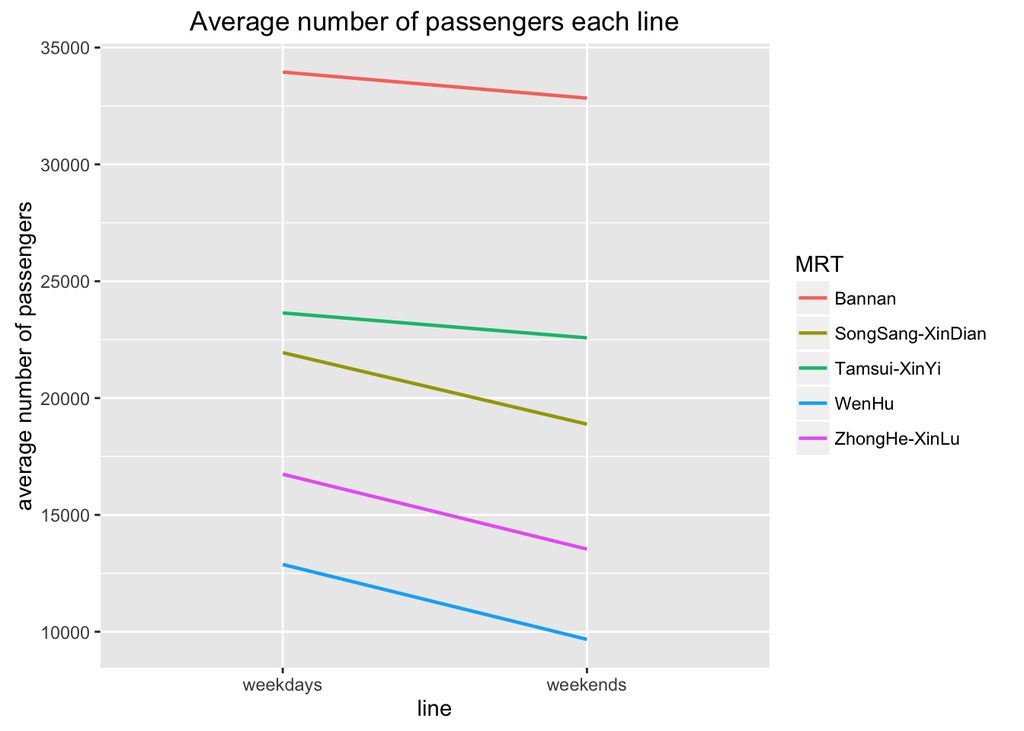

```r
ggplot(df, aes(x=week, y=avg, colour=MRT, group=MRT, fill=MRT)) +
  geom_line(size=0.8)+
  labs(title="Average number of passengers each line", x="line", y="average number of passengers")
```

> 將資料分成週間、週末兩組後做t-test，檢定週間、週末的平均進站人數是否存在顯著差異
- H0：週間和週末的平均進站人數差異＝0
- 從結果來看，週間與週末平均進站人數並無顯著差異

```r
t.test(df$avg ~ df$week, data = metro, var.equal = FALSE)
```

```
##
##  Welch Two Sample t-test
##
## data:  df$avg by df$week
## t = 0.43471, df = 7.9038, p-value = 0.6754
## alternative hypothesis: true difference in means is not equal to 0
## 95 percent confidence interval:
##  -10068.53  14734.27
## sample estimates:
## mean in group weekdays mean in group weekends
##               21833.57               19500.71
```

## 四、月份和星期效應

比較完週間週末的差異後，我們想針對一年份的資料做月份的比較。

### 使用ggplot2、dplyr、plotly三個套件。

```r
require(ggplot2)
require(dplyr)
require(plotly)
```

利用group_by()將資料依照“月份”、“週間/週末”分類，再分別計算出這24個類別的平均人數，並儲存在data1的變數中。 使用as.factor()將“月份”的資料型態轉為factor，以利之後繪圖的易讀性。 再使用ggplot()，對data1做繪圖，x軸為月份、y軸為平均人數、紅線為週間、藍線為週末。最後以ggploty()產生互動式圖表，以利讀者閱讀。

```r
data1 = metro%>%group_by(月,週末週間)%>%summarise(mean(人次))
data1$月 = as.factor(data1$月)
data1$週末週間 = as.factor(data1$週末週間)

ggplot(data=data1,aes(x=月,y=`mean(人次)`))+
  geom_line(data=data1,aes(y=`mean(人次)`,group=週末週間,colour=factor(週末週間)))+
  xlab("Month")+ylab("People")+
  labs(title = "Month & WeekCategory(Fig.4-1)",color="星期")+theme_grey(base_family = "STKaiti")
```

```r
ggplotly()
```

[interactive chart not shown]

我們可以從Fig.4-1中大致看出不同月份、週末週間平均進出人次的趨勢。 如：平均進出人次在週間比週末多、在11月、12月無論週間週末平均進出人次都有上升的趨勢。令人意外的是週末在暑假期間進出人次較低。

```r
ggplot(data=data1,aes(x=週末週間,y=`mean(人次)`))+
  geom_line(data=data1,aes(y=`mean(人次)`,group=月,colour=factor(月)))+
  xlab("週末週間")+ylab("People")+
  labs(title = "Month & WeekCategory interaction plot(Fig.4-2)",color="月")+theme_grey(base_family = "STKaiti")
```

```r
ggplotly()
```

[interactive chart not shown]

我們可以從Fig.4-2中看星期效應和月份的趨勢。 如：在8月時，週間週末的平均進出人次會加大，且以週間為多。在2月時，週間週末的平均進出人次的差異趨緩。

## 總結

以 2015 年一整年的資料分析來看，週間與週末的捷運進出量是週間比較高，雖然使用 t-test 檢定後發現沒有顯著差異。各站因為其周邊地區的商業、住宅、醫院、學校等性質，會導致週間與週末的進出量差距不同。不同捷運路線也是，更可以看出不同捷運路線的載客量差別，板南線跟淡水信義線為最高，文湖線最低。最後比較月份時，可以發現十一二月載客量上升，六七八月載客量較低，但目前尚無良好解釋。